# DATA 624 Project 2

Andrew Bowen, Josh Forster, John Cruz

2024-04-25

## Introduction

New regulations are requiring ABC Beverage to understand its manufacturing process better. We will look into the predictive factors that may influence pH in this process.

## Exploratory Data Analysis

First, we’ll read in our training and testing datasets. We’ve converted them via a basic R script and they are available on our [GitHub](https://github.com/andrewbowen19/data624Presentation/tree/main/data).

```r
# Read in training and testing datasets
training <- read.csv("https://raw.githubusercontent.com/andrewbowen19/data624Presentation/main/data/train.csv")
eval <- read.csv("https://raw.githubusercontent.com/andrewbowen19/data624Presentation/main/data/test.csv")
```

We can take a brief look at our training data summary.

```r
summary(training)
```

```
##        X           Brand.Code         Carb.Volume     Fill.Ounces
##  Min.   :   1.0   Length:2571        Min.   :5.040   Min.   :23.63
##  1st Qu.: 643.5   Class :character   1st Qu.:5.293   1st Qu.:23.92
##  Median :1286.0   Mode  :character   Median :5.347   Median :23.97
##  Mean   :1286.0                      Mean   :5.370   Mean   :23.97
##  3rd Qu.:1928.5                      3rd Qu.:5.453   3rd Qu.:24.03
##  Max.   :2571.0                      Max.   :5.700   Max.   :24.32
##                                      NA's   :10      NA's   :38
##    PC.Volume       Carb.Pressure     Carb.Temp          PSC
##  Min.   :0.07933   Min.   :57.00   Min.   :128.6   Min.   :0.00200
##  1st Qu.:0.23917   1st Qu.:65.60   1st Qu.:138.4   1st Qu.:0.04800
##  Median :0.27133   Median :68.20   Median :140.8   Median :0.07600
##  Mean   :0.27712   Mean   :68.19   Mean   :141.1   Mean   :0.08457
##  3rd Qu.:0.31200   3rd Qu.:70.60   3rd Qu.:143.8   3rd Qu.:0.11200
##  Max.   :0.47800   Max.   :79.40   Max.   :154.0   Max.   :0.27000
##  NA's   :39        NA's   :27      NA's   :26      NA's   :33
##     PSC.Fill         PSC.CO2           Mnf.Flow       Carb.Pressure1
##  Min.   :0.0000   Min.   :0.00000   Min.   :-100.20   Min.   :105.6
##  1st Qu.:0.1000   1st Qu.:0.02000   1st Qu.:-100.00   1st Qu.:119.0
##  Median :0.1800   Median :0.04000   Median :  65.20   Median :123.2
##  Mean   :0.1954   Mean   :0.05641   Mean   :  24.57   Mean   :122.6
##  3rd Qu.:0.2600   3rd Qu.:0.08000   3rd Qu.: 140.80   3rd Qu.:125.4
##  Max.   :0.6200   Max.   :0.24000   Max.   : 229.40   Max.   :140.2
##  NA's   :23       NA's   :39        NA's   :2         NA's   :32
##  Fill.Pressure   Hyd.Pressure1   Hyd.Pressure2   Hyd.Pressure3
##  Min.   :34.60   Min.   :-0.80   Min.   : 0.00   Min.   :-1.20
##  1st Qu.:46.00   1st Qu.: 0.00   1st Qu.: 0.00   1st Qu.: 0.00
##  Median :46.40   Median :11.40   Median :28.60   Median :27.60
##  Mean   :47.92   Mean   :12.44   Mean   :20.96   Mean   :20.46
##  3rd Qu.:50.00   3rd Qu.:20.20   3rd Qu.:34.60   3rd Qu.:33.40
##  Max.   :60.40   Max.   :58.00   Max.   :59.40   Max.   :50.00
##  NA's   :22      NA's   :11      NA's   :15      NA's   :15
##  Hyd.Pressure4     Filler.Level    Filler.Speed   Temperature
##  Min.   : 52.00   Min.   : 55.8   Min.   : 998   Min.   :63.60
##  1st Qu.: 86.00   1st Qu.: 98.3   1st Qu.:3888   1st Qu.:65.20
##  Median : 96.00   Median :118.4   Median :3982   Median :65.60
##  Mean   : 96.29   Mean   :109.3   Mean   :3687   Mean   :65.97
##  3rd Qu.:102.00   3rd Qu.:120.0   3rd Qu.:3998   3rd Qu.:66.40
##  Max.   :142.00   Max.   :161.2   Max.   :4030   Max.   :76.20
##  NA's   :30       NA's   :20      NA's   :57     NA's   :14
```

[output cut: 17 more lines]

```
##  Min.   : 70.0   Min.   :44.00     Min.   :140.8   Min.   :5.280
##  1st Qu.:100.0   1st Qu.:46.00     1st Qu.:142.2   1st Qu.:6.540
##  Median :120.0   Median :46.00     Median :142.6   Median :6.560
##  Mean   :109.3   Mean   :47.62     Mean   :142.8   Mean   :6.897
##  3rd Qu.:120.0   3rd Qu.:50.00     3rd Qu.:143.0   3rd Qu.:7.240
##  Max.   :140.0   Max.   :52.00     Max.   :148.2   Max.   :8.620
##  NA's   :2       NA's   :12                        NA's   :9
##     Carb.Rel      Balling.Lvl
##  Min.   :4.960   Min.   :0.00
##  1st Qu.:5.340   1st Qu.:1.38
##  Median :5.400   Median :1.48
##  Mean   :5.437   Mean   :2.05
##  3rd Qu.:5.540   3rd Qu.:3.14
##  Max.   :6.060   Max.   :3.66
##  NA's   :10      NA's   :1
```

Most of the potential predictors are numeric aside from `Brand Code` and there are a good number of columns that have different numbers of null values that will need to be dealt with before getting to our models. Most of the variables have a few missing values, but MFR has around 212 which is far larger than any of the other values.

```r
dim(training)
```

```
## [1] 2571   34
```

There are only 2,571 records in the entire dataset which isn’t that much to build a model off of, but using Cross Validation should hopefully allow for enough resampled cuts to be able to predict on unseen data. There are 32 potential predictors as it appears `X` is a row counter that can be ignored.

```r
training <-
  training |>
  dplyr::select(-X) |>
  relocate(PH)

eval <-
  eval |>
  dplyr::select(-X) |>
  relocate(PH)
```

We can take a look at the distribution of our outcome variable (`PH`)

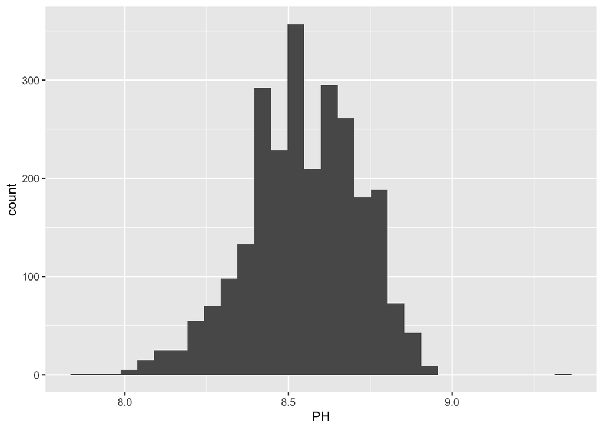

```r
# Plot pH level distribution: our output variable
ggplot(training, aes(x=PH)) + geom_histogram()
```

Most of the data is concentrated around a 8.5 pH level which are all bases above 7.0 and there is a slight left skew that exists in the data. There is one or a few very large outliers that exist on the right end of the data that probably need to be explored further as they may skew certain types of models.

### Data Wrangling

```r
# Convert Brand.Code to a factor as it's categorical
training$Brand.Code <- as.factor(training$Brand.Code)
eval$Brand.Code <- as.factor(eval$Brand.Code)
```

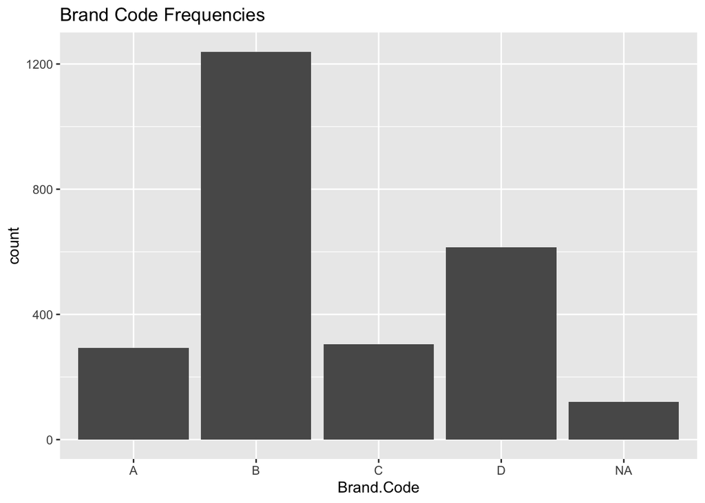

```r
ggplot(training, aes(x=Brand.Code)) + geom_bar() +
    labs(title='Brand Code Frequencies')
```

There are a number of null values present for this factor variable. Does that correspond with other null cases in the remainder of the predictors?

Let’s look at the concentration of null values in the factor variable:

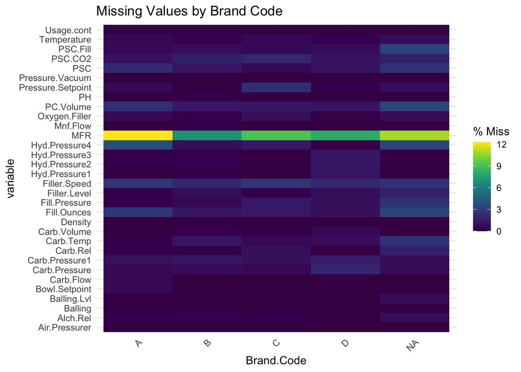

```r
naniar::gg_miss_fct(training,fct=Brand.Code) + labs(title='Missing Values by Brand Code')
```

Not that surprisingly the most common brand with missing values are the records with missing brand codes as well; however, the concentration isn’t strong enough to considering excluding all related records where brand code is missing.

### Missing Values

| PH | Brand.Code | Carb.Volume | Fill.Ounces | PC.Volume | Carb.Pressure | Carb.Temp | PSC | PSC.Fill | PSC.CO2 | Mnf.Flow | Carb.Pressure1 | Fill.Pressure | Hyd.Pressure1 | Hyd.Pressure2 | Hyd.Pressure3 | Hyd.Pressure4 | Filler.Level | Filler.Speed | Temperature | Usage.cont | Carb.Flow | Density | MFR | Balling | Pressure.Vacuum | Oxygen.Filler | Bowl.Setpoint | Pressure.Setpoint | Air.Pressurer | … |
| --- | --- | --- | --- | --- | --- | --- | --- | --- | --- | --- | --- | --- | --- | --- | --- | --- | --- | --- | --- | --- | --- | --- | --- | --- | --- | --- | --- | --- | --- | --- |
| 4 | 120 | 10 | 38 | 39 | 27 | 26 | 33 | 23 | 39 | 2 | 32 | 22 | 11 | 15 | 15 | 30 | 20 | 57 | 14 | 5 | 2 | 1 | 212 | 1 | 0 | 12 | 2 | 12 | 0 | … |

## Imputation

Our dataset is missing values, so we’ll have to impute using the `mice` library in R. For our purposes, we’ll use [predictive mean matching as our imputation method](https://stefvanbuuren.name/fimd/sec-pmm.html), since we may or may not need to transform our target variable this is a good method as it’s robust to transformations of our output variable $Y$.

```r
# Impute using the mice package
# TODO(abowen): fix imputation issue
imputed <- mice(training, meth="pmm", seed=1234, printFlag = FALSE)
```

```r
# Set the training set to be imputed values
train <- complete(imputed)
head(train)
```

```
##     PH Brand.Code Carb.Volume Fill.Ounces PC.Volume Carb.Pressure Carb.Temp
## 1 8.36          B    5.340000    23.96667 0.2633333          68.2     141.2
## 2 8.26          A    5.426667    24.00667 0.2386667          68.4     139.6
## 3 8.94          B    5.286667    24.06000 0.2633333          70.8     144.8
## 4 8.24          A    5.440000    24.00667 0.2933333          63.0     132.6
## 5 8.26          A    5.486667    24.31333 0.1113333          67.2     136.8
## 6 8.32          A    5.380000    23.92667 0.2693333          66.6     138.4
##     PSC PSC.Fill PSC.CO2 Mnf.Flow Carb.Pressure1 Fill.Pressure Hyd.Pressure1
## 1 0.104     0.26    0.04     -100          118.8          46.0             0
## 2 0.124     0.22    0.04     -100          121.6          46.0             0
## 3 0.090     0.34    0.16     -100          120.2          46.0             0
## 4 0.268     0.42    0.04     -100          115.2          46.4             0
## 5 0.026     0.16    0.12     -100          118.4          45.8             0
## 6 0.090     0.24    0.04     -100          119.6          45.6             0
##   Hyd.Pressure2 Hyd.Pressure3 Hyd.Pressure4 Filler.Level Filler.Speed
```

[output cut: 27 more lines]

```r
hist_train <- train |> dplyr::select(-c(Brand.Code))
dim(hist_train)
```

```
## [1] 2571   32
```

| PH | Brand.Code | Carb.Volume | Fill.Ounces | PC.Volume | Carb.Pressure | Carb.Temp | PSC | PSC.Fill | PSC.CO2 | Mnf.Flow | Carb.Pressure1 | Fill.Pressure | Hyd.Pressure1 | Hyd.Pressure2 | Hyd.Pressure3 | Hyd.Pressure4 | Filler.Level | Filler.Speed | Temperature | Usage.cont | Carb.Flow | Density | MFR | Balling | Pressure.Vacuum | Oxygen.Filler | Bowl.Setpoint | Pressure.Setpoint | Air.Pressurer | … |
| --- | --- | --- | --- | --- | --- | --- | --- | --- | --- | --- | --- | --- | --- | --- | --- | --- | --- | --- | --- | --- | --- | --- | --- | --- | --- | --- | --- | --- | --- | --- |
| 0 | 0 | 0 | 0 | 0 | 0 | 0 | 0 | 0 | 0 | 0 | 0 | 0 | 0 | 0 | 0 | 0 | 0 | 0 | 0 | 0 | 0 | 0 | 0 | 0 | 0 | 0 | 0 | 0 | 0 | … |

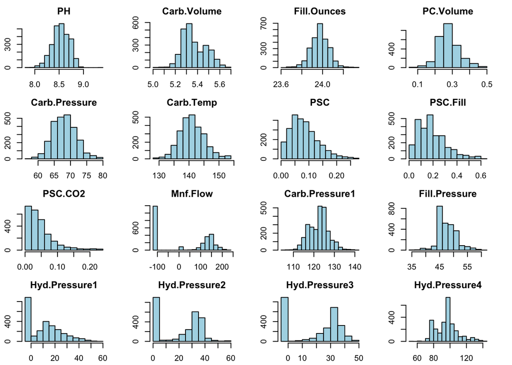

```r
fh_train <- hist_train[,1:17]
sh_train <- hist_train[,17:32]
par(mfrow=c(4,4))
par(mai=c(.3,.3,.3,.3))
train_vars <- names(fh_train)
for (i in 1:(length(train_vars)-1)) {
    hist(fh_train[[train_vars[i]]], main = train_vars[i], col = "lightblue")
}
```

The variables have been split into two groups to review their distributions and the first half of potential predictors is listed above. There are a few variables that appear to reasonably approximate a normal distribution (`Fill.Ounces`,`PC.Volume`,`Carb.Pressure`,`Carb.Temp`) and would likely not require any transformations. The variables with PSC in the name all are reasonably right skewed. There are a number of bimodal columns (Hyd.Pressure variants, `Mnf.Flow`). The remaining predictors are skewed in one direction.

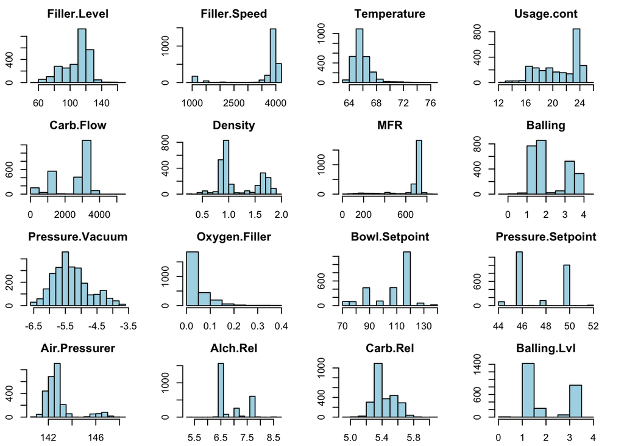

```r
par(mfrow=c(4,4))
par(mai=c(.3,.3,.3,.3))
train_sh_vars <- names(sh_train)
for (i in 1:(length(train_sh_vars))) {
    hist(sh_train[[train_sh_vars[i]]], main = train_sh_vars[i], col = "lightblue")
}
```

The second half of variables appear to be more skewed than the first half of predictors and will likely require transformation to be included in any regression model.

## Feature Selection

Next, we’ll look at the correlations between our features and output PH

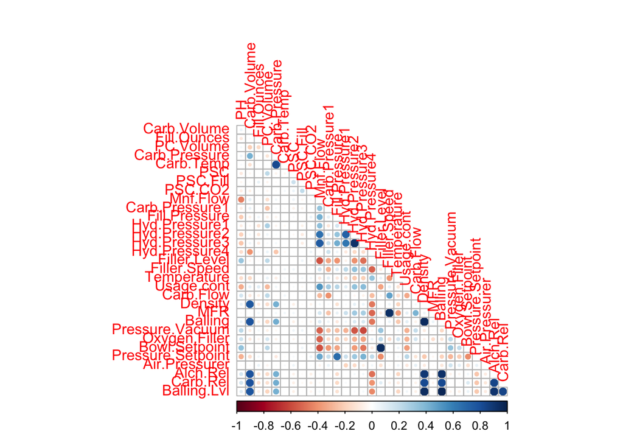

```r
correlations <- cor(as.matrix(train %>% dplyr::select(-c("Brand.Code"))))

corrplot(correlations,diag=FALSE,type='lower')
```

From a preliminary view of the correlation matrix it appears that there are several variables that are highly linearly correlated with one another.

```r
corrs_df <- as.data.frame(correlations)
corrs_df$base <- rownames(corrs_df)
corrs_df |> pivot_longer(cols=colnames(corrs_df |> dplyr::select(-base))) |>
    mutate(mod_col=ifelse(base<name,paste(base,name,sep='|'), paste(name,base,sep='|'))) |> group_by(mod_col)|> mutate(rownum=row_number()) |> filter(base!= name & rownum==1) |> dplyr::select(c(base,name,value)) |>
    arrange(-abs(value)) |> head(24)
```

```
## # A tibble: 24 × 4
## # Groups:   mod_col [24]
##    mod_col                     base          name          value
##    <chr>                       <chr>         <chr>         <dbl>
##  1 Balling|Balling.Lvl         Balling       Balling.Lvl   0.978
##  2 Balling|Density             Density       Balling       0.955
##  3 Bowl.Setpoint|Filler.Level  Filler.Level  Bowl.Setpoint 0.948
##  4 Balling.Lvl|Density         Density       Balling.Lvl   0.948
##  5 Filler.Speed|MFR            Filler.Speed  MFR           0.933
##  6 Hyd.Pressure2|Hyd.Pressure3 Hyd.Pressure2 Hyd.Pressure3 0.925
##  7 Alch.Rel|Balling            Balling       Alch.Rel      0.920
##  8 Alch.Rel|Balling.Lvl        Alch.Rel      Balling.Lvl   0.916
##  9 Alch.Rel|Density            Density       Alch.Rel      0.896
## 10 Balling.Lvl|Carb.Rel        Carb.Rel      Balling.Lvl   0.844
## # ℹ 14 more rows
```

## Modeling

We’ll train four different types of models for this regression task:

- Multiple Linear Regression
- Random Forest Regressor
- XGBoost
- Neural Net

We will split our training set into a training and holdout set so we can see how effective our models are at predicting.

We’ll finally predict on our evaluation dataset (which we’ll impute using the same method as the training dataset) using each of the models trained and write those to an output file for evaluation.

### Splitting Training Set

We will perform a 70/30 split for our training and holdout set.

```r
set.seed(123)

# index for training
index <- createDataPartition(train$PH, p = .7, list = FALSE)

# train
train_x <- train[index, ] %>% dplyr::select(-PH)
train_y <- train[index, 'PH']

# test
test_x <- train[-index, ] %>% dplyr::select(-PH)
test_y <- train[-index, 'PH']
```

### Multiple Linear Regression

First, we’ll fit a basic multiple linear regression model to our data. This can serve as a good “benchmark” model to compare our other models against , as it’s the simplest way to perform a regression task. We’ll perform a [stepwise regression task](http://www.sthda.com/english/articles/37-model-selection-essentials-in-r/154-stepwise-regression-essentials-in-r/#) to do our feature selection in an automated way, since we have so many input variables and no clear domain expertise on which would contibute most to our model.

A multiple linear regression will be used as a baseline model to see if a more simplistic and interpretable approach can be used to identify `pH`. Transformations for the predictor variable need to be considered in order to optimize the results of this model. A penalized version of the model will also be applied in order to determine if unnecessary number of predictors are included when running stepwise regression.

#### Transformation: Box-Cox

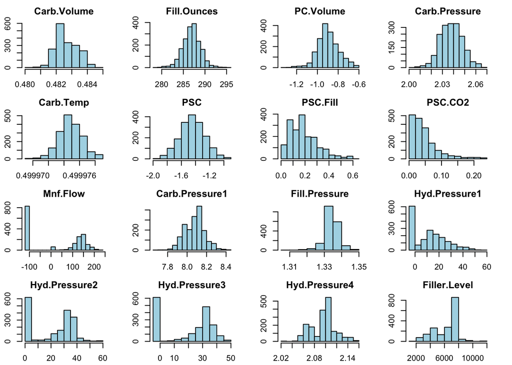

```r
x_bc <- preProcess(train_x |> dplyr::select(-c(Brand.Code)), method='BoxCox')
x_trans <- predict(x_bc,train_x |> dplyr::select(-c(Brand.Code)))
fh_x_trans <- x_trans[,1:16]
sh_x_trans <- x_trans[,17:31]

par(mfrow=c(4,4))
par(mai=c(.3,.3,.3,.3))
for (i in 1:(length(colnames(fh_x_trans)))) {
    hist(fh_x_trans[[colnames(fh_x_trans)[i]]], main = colnames(fh_x_trans)[i], col = "lightblue")
}
```

The Box-Cox transformation does not appear to have improved the `Hyd.Pressure` variables much as they mostly remain bimodally shaped although the 4th variable of this type does appear to be somewhat bell shaped. The non-normalized variables will not be excluded from the model unless they further violate key assumptions when running linear regression

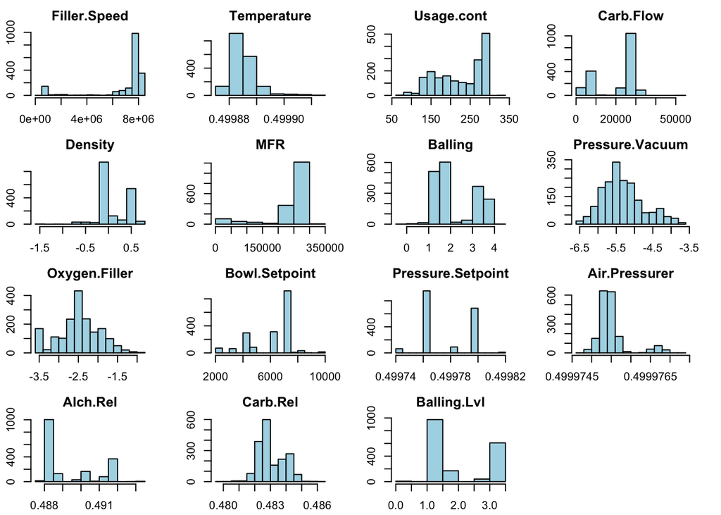

```r
par(mfrow=c(4,4))
par(mai=c(.3,.3,.3,.3))
for (i in 1:(length(colnames(sh_x_trans)))) {
    hist(sh_x_trans[[colnames(sh_x_trans)[i]]], main = colnames(sh_x_trans)[i], col = "lightblue")
}
```

The second half of predictors were more sparse in nature partially due to being discrete variables and for the most part didn’t substantially normalize after applying Box-Cox transformation.

Given that there are several highly correlated predictors, a few of them will be filtered at the beginning to prevent issues that arise from multicollinearity.

First, we’ll fit a basic multiple linear regression model to our data

```r
train_trans <- as_tibble(cbind(train_y,x_trans))
```

```r
mlmModel <- lm(train_y ~ ., train_trans |> dplyr::select(-c(Balling.Lvl,Density,MFR,Filler.Level,Hyd.Pressure3,Alch.Rel)))
step_mlr <- step(mlmModel, direction='backward', trace=0)
```

```r
summary(mlmModel)
```

```
##
## Call:
## lm(formula = train_y ~ ., data = dplyr::select(train_trans, -c(Balling.Lvl,
##     Density, MFR, Filler.Level, Hyd.Pressure3, Alch.Rel)))
##
## Residuals:
##      Min       1Q   Median       3Q      Max
## -0.54722 -0.08407  0.01376  0.09494  0.69267
##
## Coefficients:
##                     Estimate Std. Error t value Pr(>|t|)
## (Intercept)        1.013e+03  7.112e+03   0.142 0.886708
## Carb.Volume        1.126e+01  1.639e+01   0.687 0.492043
## Fill.Ounces       -5.546e-03  1.726e-03  -3.214 0.001334 **
## PC.Volume         -8.526e-02  4.062e-02  -2.099 0.035934 *
## Carb.Pressure      6.473e-01  1.838e+00   0.352 0.724776
## Carb.Temp         -9.606e+02  1.105e+04  -0.087 0.930731
## PSC               -2.960e-02  2.079e-02  -1.424 0.154710
## PSC.Fill          -3.086e-02  2.974e-02  -1.038 0.299622
## PSC.CO2           -1.252e-01  7.938e-02  -1.577 0.114886
## Mnf.Flow          -5.845e-04  5.721e-05 -10.217  < 2e-16 ***
## Carb.Pressure1     3.479e-01  4.158e-02   8.368  < 2e-16 ***
## Fill.Pressure      3.573e+00  1.104e+00   3.237 0.001231 **
## Hyd.Pressure1      1.003e-04  4.591e-04   0.219 0.827030
## Hyd.Pressure2      1.528e-03  4.562e-04   3.351 0.000823 ***
## Hyd.Pressure4     -5.599e-01  2.188e-01  -2.558 0.010595 *
## Filler.Speed      -6.043e-09  2.384e-09  -2.535 0.011320 *
## Temperature       -6.693e+03  8.403e+02  -7.965 2.92e-15 ***
## Usage.cont        -3.395e-04  7.381e-05  -4.599 4.55e-06 ***
## Carb.Flow          1.645e-06  4.810e-07   3.421 0.000639 ***
## Balling           -2.789e-02  7.603e-03  -3.668 0.000251 ***
## Pressure.Vacuum    1.743e-03  8.424e-03   0.207 0.836060
## Oxygen.Filler     -2.578e-02  9.047e-03  -2.849 0.004433 **
## Bowl.Setpoint      2.073e-05  3.372e-06   6.148 9.66e-10 ***
## Pressure.Setpoint -1.278e+03  2.716e+02  -4.705 2.74e-06 ***
## Air.Pressurer      6.875e+03  9.121e+03   0.754 0.451110
## Carb.Rel           2.271e+01  8.950e+00   2.537 0.011259 *
## ---
## Signif. codes:  0 '***' 0.001 '**' 0.01 '*' 0.05 '.' 0.1 ' ' 1
##
## Residual standard error: 0.1425 on 1776 degrees of freedom
## Multiple R-squared:  0.327,  Adjusted R-squared:  0.3175
## F-statistic: 34.52 on 25 and 1776 DF,  p-value: < 2.2e-16
```

The model based on the f-statistic is statistically significant from an intercept only model, but there are a number of insignificant predictors present when considering all of the remaining input variables.

Is there still multicollinearity?

```r
vif(mlmModel)
```

```
##       Carb.Volume       Fill.Ounces         PC.Volume     Carb.Pressure
##         11.518079          1.129373          1.573656         28.820731
##         Carb.Temp               PSC          PSC.Fill           PSC.CO2
##         24.272210          1.135057          1.085965          1.061259
##          Mnf.Flow    Carb.Pressure1     Fill.Pressure     Hyd.Pressure1
##          4.170854          1.588054          2.042694          2.906275
##     Hyd.Pressure2     Hyd.Pressure4      Filler.Speed       Temperature
##          4.937338          2.001540          2.321390          1.321504
##        Usage.cont         Carb.Flow           Balling   Pressure.Vacuum
##          1.738194          2.117928          4.517185          2.001201
##     Oxygen.Filler     Bowl.Setpoint Pressure.Setpoint     Air.Pressurer
##          1.979911          2.439828          2.271535          1.185321
##          Carb.Rel
##          4.614919
```

Yes, there is substantial variance inflation factor scores in `Carb.Volume`, `Carb.Pressure`, and `Carb.Temp` that would need to be dealt with which would nullify the validity of this model. Therefore, no other assumptions in the residuals will be evaluated.

Will stepwise regression eliminate linearly related predictors from the full model?

```r
summary(step_mlr)
```

```
##
## Call:
## lm(formula = train_y ~ Carb.Volume + Fill.Ounces + PC.Volume +
##     PSC + PSC.CO2 + Mnf.Flow + Carb.Pressure1 + Fill.Pressure +
##     Hyd.Pressure2 + Hyd.Pressure4 + Filler.Speed + Temperature +
##     Usage.cont + Carb.Flow + Balling + Oxygen.Filler + Bowl.Setpoint +
##     Pressure.Setpoint + Carb.Rel, data = dplyr::select(train_trans,
##     -c(Balling.Lvl, Density, MFR, Filler.Level, Hyd.Pressure3,
##         Alch.Rel)))
##
## Residuals:
##      Min       1Q   Median       3Q      Max
## -0.54892 -0.08377  0.01433  0.09734  0.68961
##
## Coefficients:
##                     Estimate Std. Error t value Pr(>|t|)
## (Intercept)        3.960e+03  4.287e+02   9.237  < 2e-16 ***
## Carb.Volume        1.365e+01  8.914e+00   1.531 0.125917
## Fill.Ounces       -5.558e-03  1.719e-03  -3.234 0.001242 **
## PC.Volume         -8.430e-02  3.908e-02  -2.157 0.031133 *
## PSC               -3.205e-02  2.034e-02  -1.576 0.115209
## PSC.CO2           -1.415e-01  7.766e-02  -1.822 0.068669 .
## Mnf.Flow          -5.839e-04  5.670e-05 -10.297  < 2e-16 ***
## Carb.Pressure1     3.463e-01  4.091e-02   8.465  < 2e-16 ***
## Fill.Pressure      3.548e+00  1.100e+00   3.226 0.001278 **
## Hyd.Pressure2      1.519e-03  2.999e-04   5.066 4.49e-07 ***
## Hyd.Pressure4     -5.685e-01  2.184e-01  -2.602 0.009336 **
## Filler.Speed      -5.834e-09  2.313e-09  -2.522 0.011752 *
## Temperature       -6.698e+03  8.361e+02  -8.011 2.04e-15 ***
## Usage.cont        -3.461e-04  7.302e-05  -4.740 2.31e-06 ***
## Carb.Flow          1.647e-06  4.794e-07   3.436 0.000604 ***
## Balling           -2.803e-02  7.333e-03  -3.822 0.000137 ***
## Oxygen.Filler     -2.523e-02  8.994e-03  -2.805 0.005092 **
## Bowl.Setpoint      2.024e-05  3.242e-06   6.244 5.32e-10 ***
## Pressure.Setpoint -1.254e+03  2.688e+02  -4.667 3.29e-06 ***
## Carb.Rel           2.439e+01  8.680e+00   2.810 0.005011 **
## ---
## Signif. codes:  0 '***' 0.001 '**' 0.01 '*' 0.05 '.' 0.1 ' ' 1
##
## Residual standard error: 0.1424 on 1782 degrees of freedom
## Multiple R-squared:  0.3257, Adjusted R-squared:  0.3185
## F-statistic:  45.3 on 19 and 1782 DF,  p-value: < 2.2e-16
```

Not all of the remaining predictors appear to be statistically significant although this model should have a lower AIC score compared to other model variants reviewed with backward testing. Overall, it only looks to predict approximately 32% of the variability in `PH` which does not seem to be very accurate although it’ll depend on the performance of the remaining models.

Is multicollinearity addressed as compared to the full model?

```r
vif(step_mlr)
```

```
##       Carb.Volume       Fill.Ounces         PC.Volume               PSC
##          3.412801          1.121673          1.459155          1.087188
##           PSC.CO2          Mnf.Flow    Carb.Pressure1     Fill.Pressure
##          1.017164          4.102972          1.539508          2.030475
##     Hyd.Pressure2     Hyd.Pressure4      Filler.Speed       Temperature
##          2.136616          1.997039          2.189480          1.310200
##        Usage.cont         Carb.Flow           Balling     Oxygen.Filler
##          1.703486          2.107108          4.207683          1.959630
##     Bowl.Setpoint Pressure.Setpoint          Carb.Rel
##          2.258111          2.227687          4.347342
```

Yes, while `Mnf.Flow` and `Balling` is over 4 all of the predictors have a score under 5.

Do the residuals follow the key assumptions?

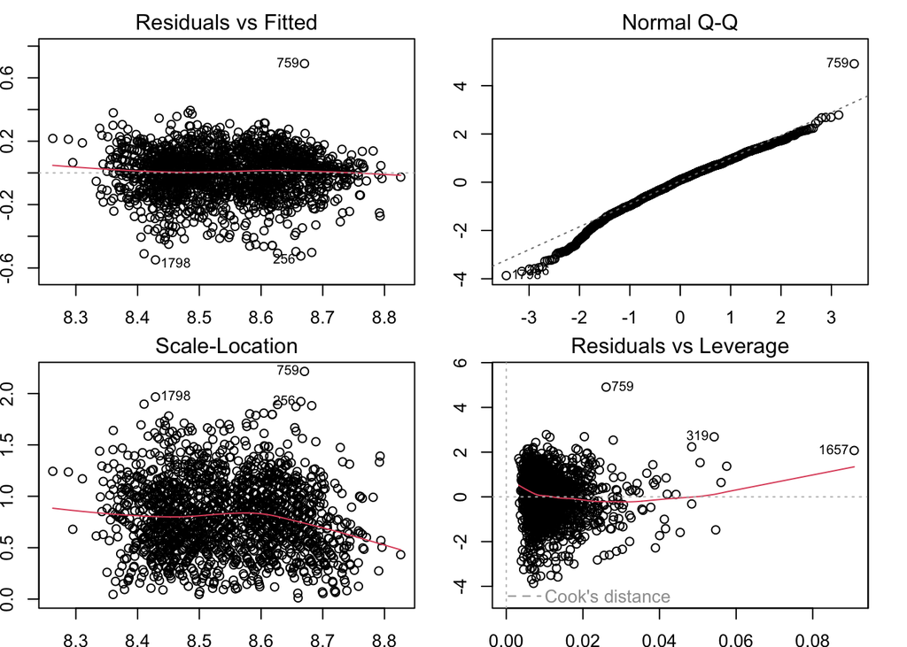

```r
par(mfrow=c(2,2))
par(mai=c(.3,.3,.3,.3))
plot(step_mlr)
```

Given the fact that the standard linear regression has an $R^2$ of ~32% let’s see if a penalized version can improve the results in a training set:

```r
class(train_y)
```

```
## [1] "numeric"
```

```r
set.seed(21)
x_Train <- as.matrix(as.data.frame(train_x |> dplyr::select(-c(Brand.Code))))
y_Train <- train_y
train_lasso <- train(x=x_Train, y=y_Train,
                 method='lasso',
                  tuneGrid=data.frame(.fraction = seq(0, 0.5, by=0.01)),
                  trControl=trainControl(method='cv'),
                  preProcess=c('center','scale'))
```

```r
train_lasso
```

```
## The lasso
##
## 1802 samples
##   31 predictor
##
## Pre-processing: centered (31), scaled (31)
## Resampling: Cross-Validated (10 fold)
## Summary of sample sizes: 1622, 1623, 1622, 1622, 1621, 1623, ...
## Resampling results across tuning parameters:
##
##   fraction  RMSE       Rsquared   MAE
##   0.00      0.1723879        NaN  0.1384537
##   0.01      0.1695338  0.1866268  0.1359337
##   0.02      0.1669186  0.1866268  0.1336570
##   0.03      0.1645537  0.1866268  0.1316086
##   0.04      0.1624501  0.1866268  0.1297674
##   0.05      0.1606390  0.1871701  0.1281232
##   0.06      0.1591271  0.1933318  0.1268667
##   0.07      0.1577710  0.2004792  0.1256801
##   0.08      0.1566177  0.2090224  0.1246502
##   0.09      0.1555557  0.2180855  0.1237355
##   0.10      0.1545576  0.2265294  0.1229159
##   0.11      0.1536117  0.2339854  0.1221268
##   0.12      0.1527418  0.2401145  0.1213759
##   0.13      0.1519569  0.2449939  0.1207201
##   0.14      0.1512931  0.2486137  0.1201648
##   0.15      0.1507490  0.2523110  0.1196876
##   0.16      0.1501716  0.2573610  0.1191777
##   0.17      0.1496328  0.2618738  0.1186756
##   0.18      0.1491187  0.2660277  0.1181922
##   0.19      0.1486633  0.2695306  0.1177641
##   0.20      0.1482594  0.2725541  0.1173775
##   0.21      0.1478849  0.2755515  0.1170126
##   0.22      0.1475301  0.2787040  0.1166632
##   0.23      0.1471846  0.2817110  0.1163203
##   0.24      0.1468633  0.2844178  0.1159962
##   0.25      0.1465745  0.2867555  0.1156948
##   0.26      0.1463066  0.2888598  0.1154058
##   0.27      0.1460670  0.2907015  0.1151310
##   0.28      0.1458561  0.2922529  0.1148625
```

[output cut: 10 more lines]

```
##   0.39      0.1437775  0.3109741  0.1123200
##   0.40      0.1436219  0.3123475  0.1121322
##   0.41      0.1434769  0.3136070  0.1119576
##   0.42      0.1433359  0.3148188  0.1117852
##   0.43      0.1431976  0.3159996  0.1116119
##   0.44      0.1430640  0.3171304  0.1114387
##   0.45      0.1429364  0.3182046  0.1112701
##   0.46      0.1428173  0.3192001  0.1111068
##   0.47      0.1427077  0.3201028  0.1109491
##   0.48      0.1426021  0.3209706  0.1107922
##   0.49      0.1425004  0.3218031  0.1106438
##   0.50      0.1424053  0.3225768  0.1105080
##
## RMSE was used to select the optimal model using the smallest value.
## The final value used for the model was fraction = 0.5.
```

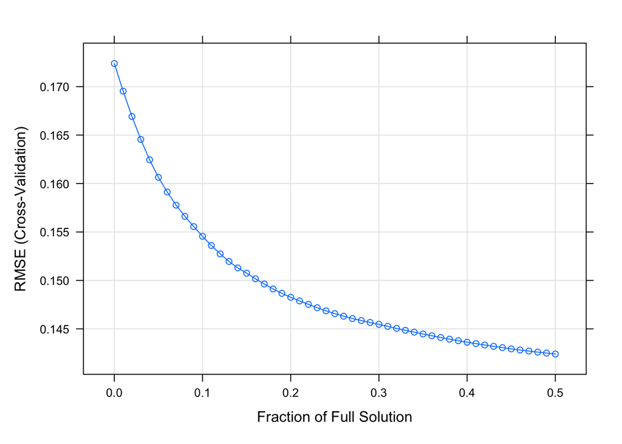

```r
plot(train_lasso)
```

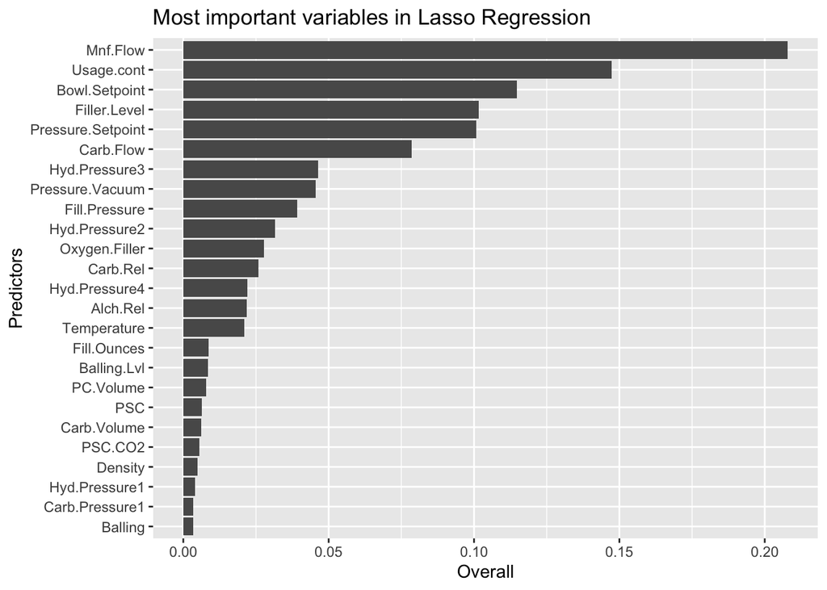

```r
lasso_var_imp <- varImp(train_lasso,scale=FALSE)
top_lasso_df <- head(lasso_var_imp$importance |> arrange(-Overall),25)

ggplot(data=top_lasso_df,aes(x=Overall,y=reorder(rownames(top_lasso_df),Overall))) +
    geom_bar(stat='identity') +
    labs(title='Most important variables in Lasso Regression',y='Predictors')
```

The lasso regression model identified the `Mnf.Flow` as the most significant predictor in the model which is somewhat separated from the next most influential variables which appear to be closely aligned in a second tier. The model itself did not appear to substantially outperform standard linear regression based on the $R^2$ statistic of 0.3225768.

Let’s try another penalized regression model, the elasticnet, to see if there is any improved performance:

```r
set.seed(6)
tr_ctrl <- trainControl(method = "cv", number = 10)
# Grid search for optimized penalty lambdas
enet_gs <- expand.grid(.lambda = c(0, 0.01, .1), .fraction = seq(.05, 1, length = 20))

# tuning penalized regression model
enet_fit <- train(x_Train, y_Train, method = "enet",
                  tuneGrid = enet_gs, trControl = tr_ctrl, preProc = c("center", "scale"))
```

```r
enet_fit
```

```
## Elasticnet
##
## 1802 samples
##   31 predictor
##
## Pre-processing: centered (31), scaled (31)
## Resampling: Cross-Validated (10 fold)
## Summary of sample sizes: 1621, 1623, 1621, 1622, 1623, 1622, ...
## Resampling results across tuning parameters:
##
##   lambda  fraction  RMSE       Rsquared   MAE
##   0.00    0.05      0.1605964  0.1872107  0.1280493
##   0.00    0.10      0.1543887  0.2290036  0.1227534
##   0.00    0.15      0.1505008  0.2558431  0.1194334
##   0.00    0.20      0.1481035  0.2749372  0.1172117
##   0.00    0.25      0.1465068  0.2877262  0.1156330
##   0.00    0.30      0.1454806  0.2954773  0.1144452
##   0.00    0.35      0.1444745  0.3049022  0.1132997
##   0.00    0.40      0.1436096  0.3126475  0.1122895
##   0.00    0.45      0.1429126  0.3185274  0.1113999
##   0.00    0.50      0.1423595  0.3229983  0.1106550
##   0.00    0.55      0.1419364  0.3263751  0.1100695
##   0.00    0.60      0.1415792  0.3293327  0.1096029
##   0.00    0.65      0.1413671  0.3311533  0.1092953
##   0.00    0.70      0.1413515  0.3315745  0.1091849
##   0.00    0.75      0.1413633  0.3316652  0.1091058
##   0.00    0.80      0.1413432  0.3318734  0.1090134
##   0.00    0.85      0.1413376  0.3319374  0.1089456
##   0.00    0.90      0.1413651  0.3317309  0.1089172
##   0.00    0.95      0.1414183  0.3313326  0.1089160
##   0.00    1.00      0.1415093  0.3306047  0.1089496
##   0.01    0.05      0.1621061  0.1865693  0.1294214
##   0.01    0.10      0.1561451  0.2136511  0.1242089
##   0.01    0.15      0.1521487  0.2453294  0.1208694
##   0.01    0.20      0.1495895  0.2633158  0.1186152
##   0.01    0.25      0.1478252  0.2768035  0.1169581
##   0.01    0.30      0.1465236  0.2872456  0.1156696
##   0.01    0.35      0.1456415  0.2938640  0.1146685
##   0.01    0.40      0.1448015  0.3017168  0.1137171
##   0.01    0.45      0.1440439  0.3086227  0.1128300
```

[output cut: 19 more lines]

```
##   0.10    0.45      0.1461229  0.2874626  0.1153095
##   0.10    0.50      0.1455422  0.2928264  0.1146628
##   0.10    0.55      0.1450374  0.2975091  0.1140919
##   0.10    0.60      0.1446248  0.3013414  0.1136174
##   0.10    0.65      0.1442301  0.3050283  0.1131596
##   0.10    0.70      0.1438210  0.3088676  0.1127080
##   0.10    0.75      0.1434259  0.3125745  0.1122868
##   0.10    0.80      0.1430781  0.3158285  0.1119122
##   0.10    0.85      0.1427828  0.3185946  0.1115710
##   0.10    0.90      0.1425400  0.3208955  0.1112613
##   0.10    0.95      0.1423691  0.3225706  0.1110055
##   0.10    1.00      0.1422909  0.3234422  0.1108282
##
## RMSE was used to select the optimal model using the smallest value.
## The final values used for the model were fraction = 0.85 and lambda = 0.
```

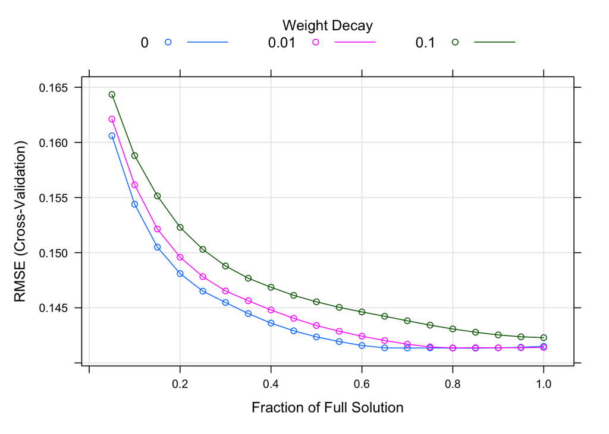

```r
plot(enet_fit)
```

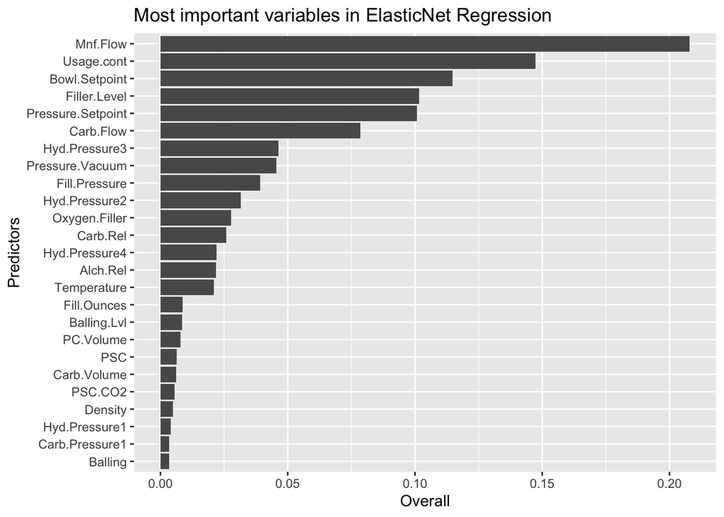

```r
enet_var_imp <- varImp(enet_fit,scale=FALSE)
top_enet_df <- head(enet_var_imp$importance |> arrange(-Overall),25)

ggplot(data=top_enet_df,aes(x=Overall,y=reorder(rownames(top_enet_df),Overall))) +
    geom_bar(stat='identity') +
    labs(title='Most important variables in ElasticNet Regression',y='Predictors')
```

### Random Forest

We’ll train a random forest to predict the `PH` variable as well. Random forests are an ensemble method based on training several decision trees

```r
# Train random forest mdoel
set.seed(12345)
rfModel <- randomForest(train_y ~ ., data = train_x)
```

```r
rfModel
```

```
##
## Call:
##  randomForest(formula = train_y ~ ., data = train_x)
##                Type of random forest: regression
##                      Number of trees: 500
## No. of variables tried at each split: 10
##
##           Mean of squared residuals: 0.0102825
##                     % Var explained: 65.43
```

```r
rf_imp <- as.data.frame(importance(rfModel))
rf_imp |> arrange(-IncNodePurity)
```

```
##                   IncNodePurity
## Mnf.Flow              6.3811739
## Brand.Code            4.2171118
## Usage.cont            3.8413510
## Filler.Level          2.6751280
## Oxygen.Filler         2.2853977
## Temperature           2.1639040
## Carb.Rel              1.9371104
## Pressure.Vacuum       1.9206118
## Bowl.Setpoint         1.9115285
## Balling.Lvl           1.8785168
## Alch.Rel              1.7593908
## Carb.Pressure1        1.6848685
## Balling               1.6005021
## Air.Pressurer         1.4447594
## Carb.Flow             1.4215838
## Filler.Speed          1.3649260
## Density               1.2848704
## Hyd.Pressure3         1.1486062
## MFR                   1.1271471
## Fill.Pressure         1.0104228
## PC.Volume             0.9921851
## Carb.Volume           0.9788374
## Pressure.Setpoint     0.9410968
## Fill.Ounces           0.8543457
## Hyd.Pressure2         0.8209298
## PSC                   0.7966784
## Hyd.Pressure4         0.7921745
## Hyd.Pressure1         0.7310677
## Carb.Pressure         0.6782419
## Carb.Temp             0.6568891
## PSC.Fill              0.6478960
## PSC.CO2               0.4397578
```

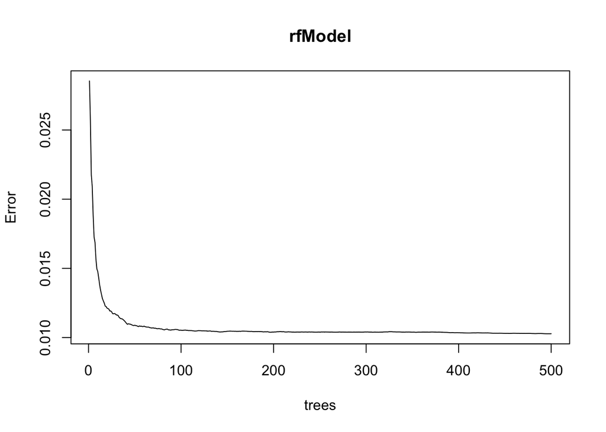

```r
plot(rfModel)
```

Reviewing the error rates across the different number of trees used in the model it appears that the rate tapers off around 50 or so trees; however, the random forest algorithm is less likely to overfit than other machine learning varieties with additional decision trees.

### Neural Network

We’ll use the `nnet` package in R to train a neural net on our dataset.

```r
myControl <- trainControl(## 3-fold CV
    method = "cv",
    number = 3)

nnGrid <-  expand.grid(size = seq(1, 10, 3),
                         decay = c(0, 0.2, 0.4))

ntrain <- cbind(train_y, train_x)

# Train neural net model
nnModel <- train(train_y ~ .,
                   data = ntrain,
                   method = "nnet",
                   maxit = 1000,
                   tuneGrid = nnGrid,
                   trainControl = myControl, trace = FALSE)
```

We’ll plot our tuning loss as a function of our hyperparameter tuning

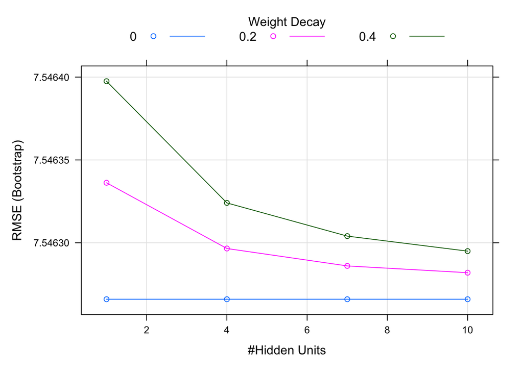

```r
plot(nnModel)
```

The weight decay appears to be lowest with no weight decay although the although parameters appears to decrease to a similar RMSE with more hidden layers in the network.

### XGBoost

One other popular method is that of XGBoost. This is a boosting method using gradient descent to minimize the loss function. It is a slightly different approach to Random forests that independantly evaluate and aggregate tree results, while XGBoost attempts to leverage prior tree learnings with each additional decision tree.

```r
# Set up parameter grid for XG Boost tuning
param <-  data.frame(nrounds=c(100), max_depth = c(1:10), eta=c(0.3), gamma=seq(0, 0.9, 0.1),
                     colsample_bytree=c(0.8), min_child_weight=c(1), subsample=c(1))

# Train XGBoost using Repeated crossfold validation
xgBoostModel <- train(train_y~., data=ntrain, method="xgbTree",
                      trControl=trainControl(method="repeatedcv"), tuneGrid=param)
```

Now we can plot our XGBoost model’s hyperparameter tuning results

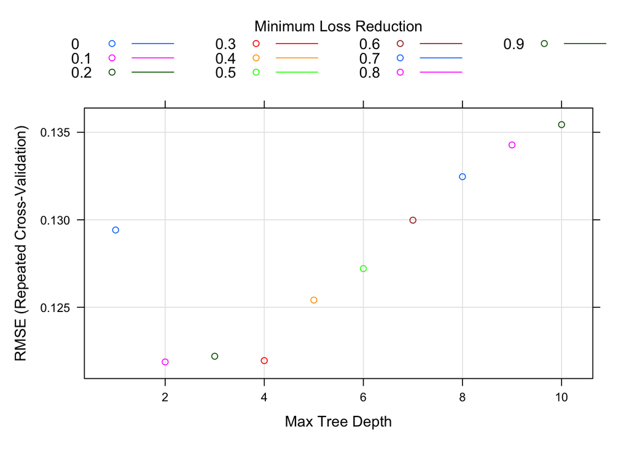

```r
plot(xgBoostModel)
```

## Model Evalutation

Now we can use the four models we’ve trained and test our holdset on it. This will allow us to evaluate the predictors and its effectiveness

```r
# Predict using all trained models
predictionsLinear <- predict(mlmModel, test_x)
predictionsRandomForest <- predict(rfModel, test_x)
predictionsNN <- predict(nnModel, test_x )
predictionsXGBoost <- predict(xgBoostModel, test_x)
```

The model with the best prediction performance is the Random Forest model with an $R^2 = 0.6698$ and the lowest $RMSE = 0.1020$

```r
mlm_perf <- as_tibble(as.list(postResample(predictionsLinear, test_y))) %>%
  mutate(Model = "Linear Reg") |>
  relocate(Model)
rf_perf <- as_tibble(as.list(postResample(predictionsRandomForest, test_y)))%>%
  mutate(Model = "Random Forest") |>
  relocate(Model)
nn_perf <- as_tibble(as.list(postResample(predictionsNN, test_y)))%>%
  mutate(Model = "Neural Net")|>
  relocate(Model)
xg_perf <- as_tibble(as.list(postResample(predictionsXGBoost, test_y)))%>%
  mutate(Model = "XGBoost")|>
  relocate(Model)

models_performance <- rbind(mlm_perf, rf_perf, nn_perf, xg_perf)

kbl(models_performance |> arrange(RMSE), digits = 4, caption = "Model Performance") |>
  kable_classic(full_width = F, html_font = "Cambria") |>
  kable_styling(latex_options = "HOLD_position") |>
  row_spec(1, bold = T, color = "white", background = "#D7261E")
```

Model Performance

| Model | RMSE | Rsquared | MAE |
| --- | --- | --- | --- |
| Random Forest | 0.1020 | 0.6698 | 0.0734 |
| XGBoost | 0.1229 | 0.4976 | 0.0947 |
| Neural Net | 7.5522 | NA | 7.5503 |
| Linear Reg | 345758.9319 | 0.0168 | 345518.4869 |

#### Variable Importance

We can see that in 3 out of our 4 main models, within the top 10 predictors, we have `Mnf.Flow` as a key important variable in our models. Interestingly enough, our Neural Net model shows `filler.speed` as the most important variable, however, it does not fall into any of our other models top 10 at all.

```r
var_imp_table <- function(model_name, tbl_name) {

    if (tbl_name != "Neural Net" && tbl_name != "XGBoost") {
      var_imp <- varImp(model_name, scale = FALSE)

      var_imp <- var_imp %>%
        arrange(-(Overall)) %>%
          mutate(Rank = 1:nrow(var_imp))  %>%
        head(., 10)
        }
    else {
      var_imp <- varImp(model_name, scale = FALSE)
      var_imp <- var_imp$importance

      var_imp <- var_imp %>%
        arrange(-Overall) %>%
          mutate(Rank = 1:nrow(var_imp)) %>%
        head(., 10)
      }

  kbl(var_imp,
    caption = paste0(tbl_name," Variable Importance"),
    digits=4) |>
  kable_classic(full_width = F, html_font = "Cambria") |>
  footnote(general_title = "") |>
    row_spec(which(var_imp$Rank==1), bold = T, color = "white", background = "red")
}

#par(mfrow=c(4,4))
#par(mai=c(.3,.3,.3,.3))

var_imp_table(mlmModel, "Linear Regression")
```

Linear Regression Variable Importance

|  | Overall | Rank |
| --- | --- | --- |
| Mnf.Flow | 10.2168 | 1 |
| Carb.Pressure1 | 8.3684 | 2 |
| Temperature | 7.9653 | 3 |
| Bowl.Setpoint | 6.1482 | 4 |
| Pressure.Setpoint | 4.7046 | 5 |
| Usage.cont | 4.5990 | 6 |
| Balling | 3.6684 | 7 |
| Carb.Flow | 3.4208 | 8 |
| Hyd.Pressure2 | 3.3508 | 9 |
| Fill.Pressure | 3.2368 | 10 |

```r
var_imp_table(rfModel, "Random Forest")
```

Random Forest Variable Importance

|  | Overall | Rank |
| --- | --- | --- |
| Mnf.Flow | 6.3812 | 1 |
| Brand.Code | 4.2171 | 2 |
| Usage.cont | 3.8414 | 3 |
| Filler.Level | 2.6751 | 4 |
| Oxygen.Filler | 2.2854 | 5 |
| Temperature | 2.1639 | 6 |
| Carb.Rel | 1.9371 | 7 |
| Pressure.Vacuum | 1.9206 | 8 |
| Bowl.Setpoint | 1.9115 | 9 |
| Balling.Lvl | 1.8785 | 10 |

```r
var_imp_table(nnModel, "Neural Net")
```

Neural Net Variable Importance

|  | Overall | Rank |
| --- | --- | --- |
| Filler.Speed | 52.8166 | 1 |
| MFR | 5.7060 | 2 |
| Carb.Temp | 5.6210 | 3 |
| Air.Pressurer | 5.3660 | 4 |
| Carb.Pressure1 | 4.9543 | 5 |
| Filler.Level | 4.1279 | 6 |
| Bowl.Setpoint | 4.1193 | 7 |
| Hyd.Pressure4 | 3.4544 | 8 |
| Carb.Pressure | 2.8613 | 9 |
| Temperature | 2.5664 | 10 |

```r
var_imp_table(xgBoostModel, "XGBoost")
```

XGBoost Variable Importance

|  | Overall | Rank |
| --- | --- | --- |
| Mnf.Flow | 0.2004 | 1 |
| Usage.cont | 0.1071 | 2 |
| Bowl.Setpoint | 0.0792 | 3 |
| Brand.CodeC | 0.0739 | 4 |
| Carb.Pressure1 | 0.0635 | 5 |
| Temperature | 0.0577 | 6 |
| Alch.Rel | 0.0493 | 7 |
| Oxygen.Filler | 0.0432 | 8 |
| Pressure.Setpoint | 0.0393 | 9 |
| Balling | 0.0371 | 10 |

### Predictions (Evaluation Set)

We’ll need to impute our test data in order to not feed any `NaN` values into our models. We’ll use the predictive mean matching method that we used above to impute our test values.

```r
evalImputed <- mice(eval, method="pmm", seed=1234, printFlag = FALSE)
eval <- complete(evalImputed)# %>% select(-c("PH"))#, "Brand.Code"))
```

Now we can use the four models we’ve trained as options for predictions.

```r
# Predict using all trained models
predictionsLinear <- predict(mlmModel, eval)
predictionsRandomForest <- predict(rfModel, eval)
predictionsNN <- predict(nnModel, eval %>% dplyr::select(-c(PH)))
predictionsXGBoost <- predict(xgBoostModel, eval)
```

```r
predictions <- as.data.frame(cbind(linear = predictionsLinear,xgBoost = predictionsXGBoost, randomForest = predictionsRandomForest))#, neuralNet = predictionsNN)

# Replace with local path if needed
#write_csv(predictions, "/Users/andrewbowen/CUNY/data624Presentation/data/project2-predictions.csv")
write_csv(predictions,'project2_predictions.csv')
```

However, given our results our best model would be to use a Random Forest with a focus on `Mnf.Flow` in our process as a major contributor and predictor for `PH`.